# Detecting cell-cycle stage difference in glioblastoma cells

Donghyung Lee

2017-08-15

Here, we illustrate how to use the iasva package to detect cell cycle stage difference within single cell RNA sequencing data. We use single cell RNA sequencing (scRNA-Seq) data obtained from human glioblastoma samples ([Petel et. al., 2014](https://www.ncbi.nlm.nih.gov/pmc/articles/PMC4123637/)). This dataset is included in a R data package (“iasvaExamples”) containing data examples for IA-SVA (https://github.com/dleelab/iasvaExamples). To install the package, follow the instruction provided in the GitHub page.

## Install packages

```r
#devtools
library(devtools)
#iasva
devtools::install_github("UcarLab/IA-SVA")
#iasvaExamples
devtools::install_github("dleelab/iasvaExamples")
```

## Load packages

```r
rm(list=ls())
library(irlba) # partial SVD, the augmented implicitly restarted Lanczos bidiagonalization algorithm
library(iasva)
library(iasvaExamples)
library(sva)
library(Rtsne)
library(pheatmap)
library(corrplot)
library(DescTools) #pcc i.e., Pearson's contingency coefficient
library(RColorBrewer)

color.vec <- brewer.pal(3, "Set1")
```

## Load the glioblastoma single cell RNA-Seq data

```r
data("Patel_Glioblastoma_scRNAseq_Read_Counts")
data("Patel_Glioblastoma_scRNAseq_Annotations")
ls()
```

```
## [1] "color.vec"
## [2] "Patel_Glioblastoma_scRNAseq_Annotations"
## [3] "Patel_Glioblastoma_scRNAseq_Read_Counts"
```

```r
counts <- Patel_Glioblastoma_scRNAseq_Read_Counts
anns <- Patel_Glioblastoma_scRNAseq_Annotations
dim(anns)
```

```
## [1] 434   3
```

```r
dim(counts)
```

```
## [1] 25415   434
```

```r
summary(anns)
```

```
##          run      patient_id     subtype
##  SRR1294493:  1   MGH26:118   None   :120
##  SRR1294494:  1   MGH28: 95   Mes    :103
##  SRR1294496:  1   MGH29: 76   Pro    : 89
##  SRR1294498:  1   MGH30: 74   Cla    : 46
##  SRR1294499:  1   MGH31: 71   Neu    : 24
##  SRR1294500:  1               Pro+Cla: 20
##  (Other)   :428               (Other): 32
```

```r
table(anns$patient_id, anns$subtype)
```

```
##
##         Cla Cla+Mes Mes Neu Neu+Cla Neu+Mes None Pro Pro+Cla Pro+Neu
##   MGH26  10       0   0   1       1       0   19  71      14       2
##   MGH28   1       5  56   0       0       7   21   5       0       0
##   MGH29   0       0  28  12       0      12   19   4       0       1
##   MGH30  33       1   8   1       1       0   16   6       6       2
##   MGH31   2       0  11  10       0       0   45   3       0       0
```

```r
ContCoef(table(anns$patient_id, anns$subtype))
```

```
## [1] 0.723431
```

The annotations describing the glioblastoma samples and experimental settings are stored in “anns” and the read counts information is stored in “counts”.

## Extract glioblastoma cells from Patient MGH30

We use read counts of glioblastoma cells from Patient MGH30 (n = 58).

```r
counts <- counts[, (anns$subtype!="None")&(anns$patient_id=="MGH30")]
anns <- subset(anns, (subtype!="None")&(patient_id=="MGH30"))
dim(counts)
```

[1] 25415 58

```r
dim(anns)
```

[1] 58 3

```r
anns <- droplevels(anns)

prop.zeros <- sum(counts==0)/length(counts)
prop.zeros
```

[1] 0.6279118

```r
# filter out genes that are sparsely and lowly expressed
filter = apply(counts, 1, function(x) length(x[x>5])>=3)

counts = counts[filter,]
dim(counts)
```

[1] 21151 58

```r
prop.zeros <- sum(counts==0)/length(counts)
prop.zeros
```

[1] 0.5566493

```r
Subtype <- anns$subtype
Patient_ID <- anns$patient_id
```

## Calculate geometric library size, i.e., library size of log-transfromed read counts

It is well known that the geometric library size (i.e., library size of log-transfromed read counts) or proportion of expressed genes in each cell explains a very large portion of variability of scRNA-Seq data ([Hicks et. al. 2015 BioRxiv](http://biorxiv.org/content/early/2015/08/25/025528), [McDavid et. al. 2016 Nature Biotechnology](http://www.nature.com/nbt/journal/v34/n6/full/nbt.3498.html)). Frequently, the first principal component of log-transformed scRNA-Seq read counts is highly correlated with the geometric library size (r ~ 0.9). Here, we calculate the geometric library size vector, which will be used as a known factor in the IA-SVA algorithm.

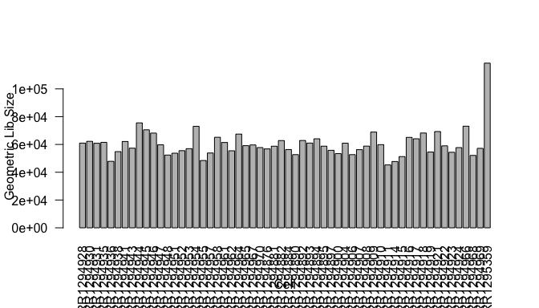

```r
Geo_Lib_Size <- colSums(log(counts+1))
barplot(Geo_Lib_Size, xlab="Cell", ylab="Geometric Lib Size", las=2)
```

```r
lcounts <- log(counts + 1)
pc1 = irlba(lcounts - rowMeans(lcounts), 1)$v[,1] ## partial SVD
cor(Geo_Lib_Size, pc1)
```

```
## [1] 0.9595776
```

## Run IA-SVA

Here, we run IA-SVA using Geo_Lib_Size as a known factor and identify five hidden factors. SVs are plotted in a pairwise fashion to uncover which SVs can seperate cells.

```r
set.seed(345)
mod <- model.matrix(~Geo_Lib_Size)
iasva.res<- iasva(t(counts), mod[,-1],verbose=FALSE, permute=FALSE, num.sv=5) ## irlba
```

```
## IA-SVA running...
## SV1 Detected!
## SV2 Detected!
## SV3 Detected!
## SV4 Detected!
## SV5 Detected!
## # of significant surrogate variables: 5
```

```r
iasva.sv <- iasva.res$sv

Cell_Cycle <- as.factor(iasva.sv[,2] > -0.1)
levels(Cell_Cycle)=c("Cycle1","Cycle2")
table(Cell_Cycle)
```

```
## Cell_Cycle
## Cycle1 Cycle2
##     12     46
```

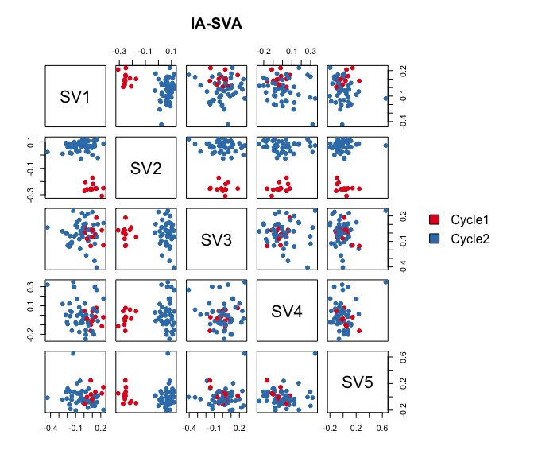

```r
pairs(iasva.sv[,1:5], main="IA-SVA", pch=21, col=color.vec[Cell_Cycle], bg=color.vec[Cell_Cycle], oma=c(4,4,6,14))
legend("right", levels(Cell_Cycle), fill=color.vec, bty="n")
```

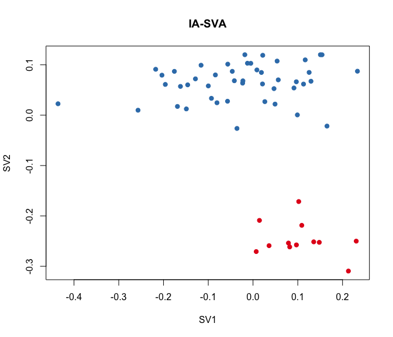

```r
plot(iasva.sv[,1:2], main="IA-SVA", pch=21, xlab="SV1", ylab="SV2", col=color.vec[Cell_Cycle], bg=color.vec[Cell_Cycle])
```

```r
#legend("bottomright", levels(Cell_Cycle), fill=color.vec, bty="n")

cor(Geo_Lib_Size, iasva.sv[,2])
```

```
## [1] -0.4870356
```

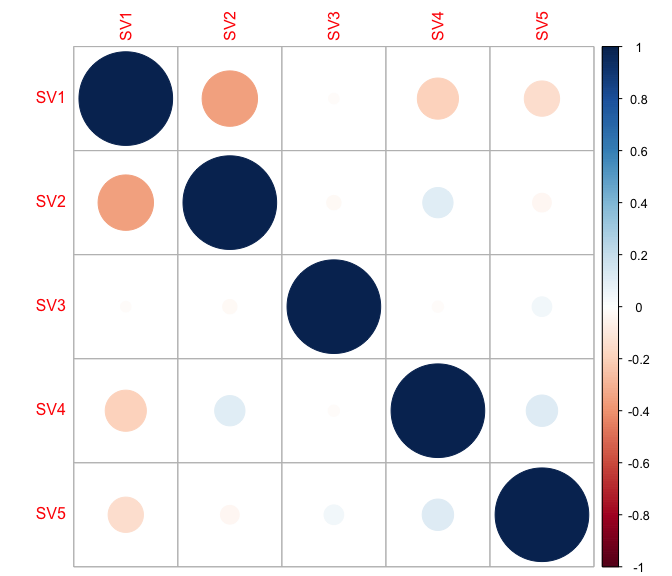

```r
corrplot(cor(iasva.sv))
```

As shown in the above figure, SV2 clearly separates glioblastoma cells into two groups: 12 cells (marked in red) and the rest of the cells (marked in blue). Note that SV2 is moderately correlated with the geometric library size (|r|=0.49). SV5 also captures an outlier cell. However, we will focus on SV2 in the rest of the analyses.

## Find marker genes for the detected heterogeneity (SV2).

Here, using the find.markers() function we find marker genes (n=87 genes) that are significantly associated with SV2 (multiple testing adjusted p-value < 0.05, default significance cutoff, and R-squared value > 0.4).

```r
marker.counts <- find.markers(t(counts), as.matrix(iasva.sv[,2]), rsq.cutoff = 0.4)
```

```
## # of markers (): 87
## total # of unique markers:  87
```

```r
nrow(marker.counts) #87 58
```

```
## [1] 87
```

```r
rownames(marker.counts)
```

```
##  [1] "NCAPD2"        "TACC3"         "SPAG5"         "UBE2T"
##  [5] "NDC80"         "RAD54L"        "TPX2"          "BIRC5"
##  [9] "KIF4A"         "ORC6"          "CLSPN"         "CDC7"
## [13] "CENPM"         "ASF1B"         "NCAPG"         "FOXM1"
## [17] "TIMELESS"      "CDCA3"         "ECT2"          "CENPF"
## [21] "KIF14"         "NCAPH"         "MND1"          "KIF18A"
## [25] "ZWINT"         "HJURP"         "DLGAP5"        "FAM64A"
## [29] "SGOL1"         "TOP2A"         "CCNB1"         "CDCA8"
## [33] "TROAP"         "TCF19"         "NRM"           "NUSAP1"
## [37] "KIF23"         "CASC5"         "KIF20B"        "CENPE"
## [41] "KIF2C"         "NUF2"          "FANCD2"        "TIFA"
## [45] "CDCA5"         "NCAPG2"        "MKI67"         "SPC25"
## [49] "SKA1"          "EME1"          "BUB1B"         "CCNB2"
## [53] "CDC25C"        "RACGAP1"       "SPC24"         "KIF15"
## [57] "POC1A"         "MAD2L1"        "PTTG1"         "MELK"
## [61] "C11orf82"      "CENPN"         "TK1"           "PBK"
## [65] "CKAP2L"        "BUB1"          "CDK1"          "SHCBP1"
## [69] "ESCO2"         "RRM2"          "UBE2C"         "TYMS"
## [73] "AURKB"         "TRAIP"         "IQGAP3"        "PARPBP"
## [77] "XRCC2"         "HMGN2"         "PRC1"          "KIF4B"
## [81] "PTTG2"         "RP11-192H23.4" "RP11-133K1.2"  "RP11-798K3.2"
## [85] "RP11-143J24.1" "CTD-2510F5.6"  "CTB-175P5.4"
```

```r
anno.col <- data.frame(Subtype=Subtype, Cell_Cycle=Cell_Cycle, Lib_Size=colSums(counts))
rownames(anno.col) <- colnames(marker.counts)
head(anno.col)
```

```
##            Subtype Cell_Cycle  Lib_Size
## SRR1294928 Pro+Cla     Cycle2  63371814
## SRR1294930     Pro     Cycle2  91372430
## SRR1294931     Cla     Cycle2  58507598
## SRR1294935     Cla     Cycle2 137157795
## SRR1294936     Cla     Cycle2  22486574
## SRR1294938     Cla     Cycle2  67682923
```

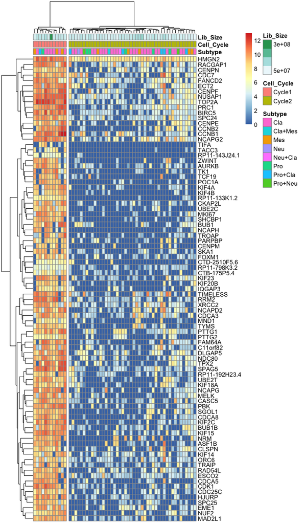

```r
pheatmap(log(marker.counts+1), show_colnames =FALSE, clustering_method = "ward.D2",cutree_cols = 2,annotation_col = anno.col)
```

Theses marker genes are strongly enriched in cell-cycle related Go terms and KEGG pathways. (See Supplementary Figure 6 in https://doi.org/10.1101/151217)

## Run tSNE to detect the hidden heterogeneity.

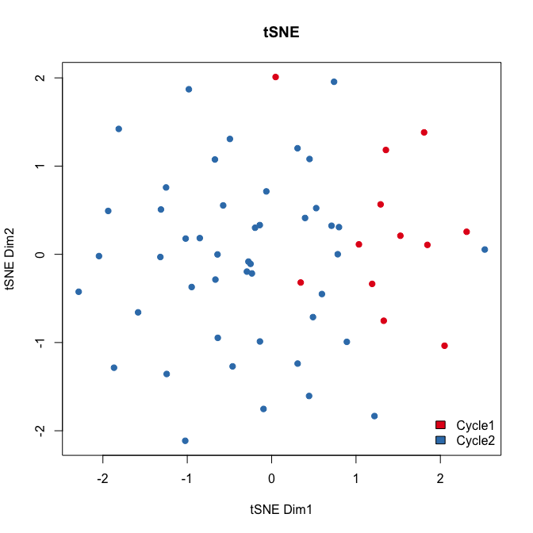

```r
set.seed(323542534)
tsne.res <- Rtsne(t(lcounts), dims = 2, perplexity = 15)

plot(tsne.res$Y, main="tSNE", xlab="tSNE Dim1", ylab="tSNE Dim2", pch=21, col=color.vec[Cell_Cycle], bg=color.vec[Cell_Cycle], oma=c(4,4,6,12))
legend("bottomright", levels(Cell_Cycle), fill=color.vec, bty="n")
```

As shown above, tSNE fails to detect the outlier cells that are identified by IA-SVA when all genes are used. Same color coding is used as above.

## Run tSNE post IA-SVA analyses, i.e., run tSNE on marker genes associated with SV2 as detected by IA-SVA.

Here, we apply tSNE on the marker genes for SV2 obtained from IA-SVA

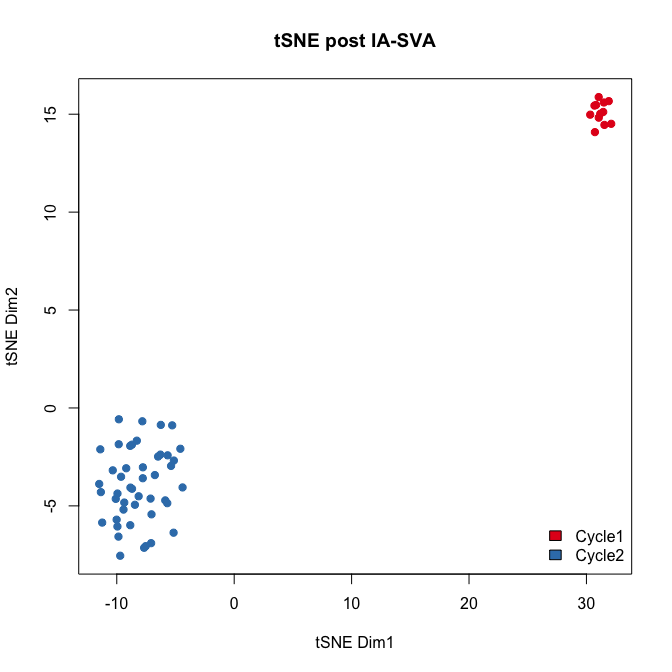

```r
set.seed(34523)
tsne.res <- Rtsne(unique(t(log(marker.counts+1))), dims = 2, perplexity = 15)

plot(tsne.res$Y, main="tSNE post IA-SVA", xlab="tSNE Dim1", ylab="tSNE Dim2", pch=21, col=color.vec[Cell_Cycle], bg=color.vec[Cell_Cycle], oma=c(4,4,6,12))
legend("bottomright", levels(Cell_Cycle), fill=color.vec, bty="n")
```

## Run principal component analysis (PCA) to detect the hidden heterogeneity (SV2).

Here, we use PCA to detect the cell cycle stage difference (SV2) detected by IA-SVA.

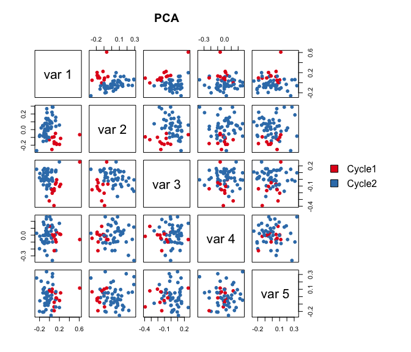

```r
pca.res = irlba(lcounts - rowMeans(lcounts), 5)$v ## partial SVD

pairs(pca.res[,1:5], main="PCA", pch=21, col=color.vec[Cell_Cycle], bg=color.vec[Cell_Cycle],
      oma=c(4,4,6,14))
legend("right", levels(Cell_Cycle), fill=color.vec, bty="n")
```

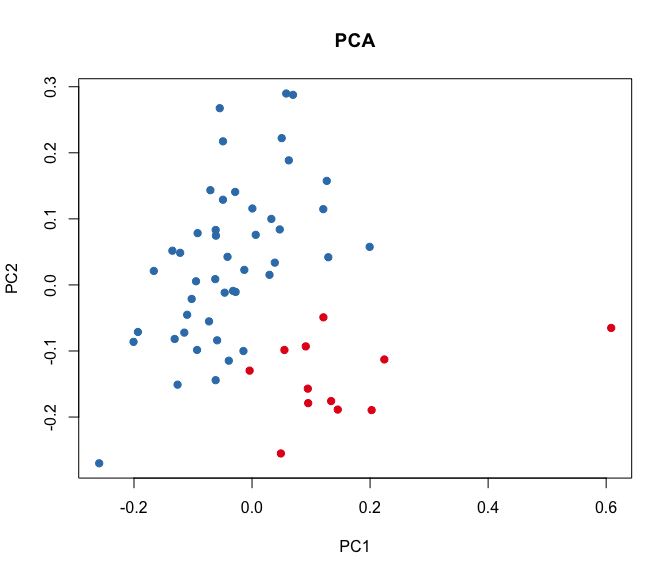

```r
plot(pca.res[,1:2], main="PCA", pch=21, xlab="PC1", ylab="PC2", col=color.vec[Cell_Cycle], bg=color.vec[Cell_Cycle])
```

PCA failed to capture the heterogeneity.

## Run surrogate variable analysis (SVA) to detect the hidden heterogeneity (SV2).

Here, for comparison purposes we use SVA to detect the hidden heterogeneity in our example data.

```r
mod1 <- model.matrix(~Geo_Lib_Size)
mod0 <- cbind(mod1[,1])

sva.res = svaseq(counts,mod1,mod0, n.sv=5)$sv
```

```
## Number of significant surrogate variables is:  5
## Iteration (out of 5 ):1  2  3  4  5
```

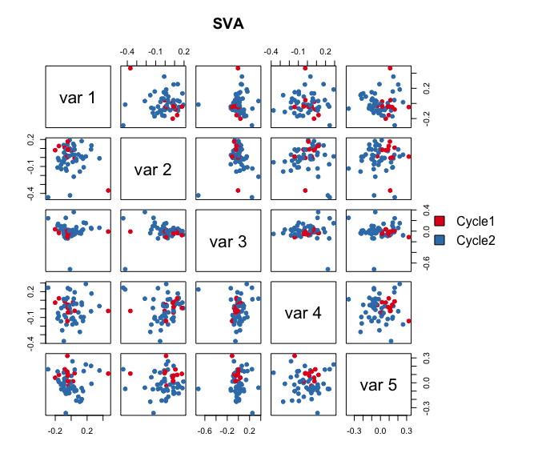

```r
pairs(sva.res[,1:5], main="SVA", pch=21, col=color.vec[Cell_Cycle], bg=color.vec[Cell_Cycle], oma=c(4,4,6,12)) #4,4,6,12
legend("right", levels(Cell_Cycle), fill=color.vec, bty="n")
```

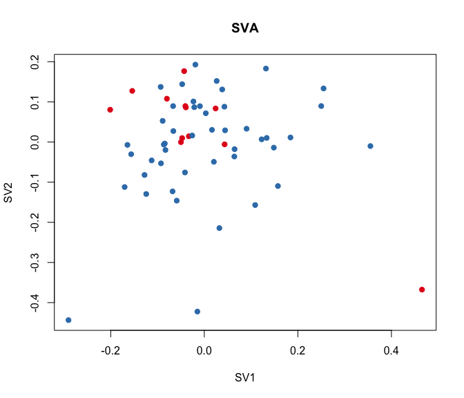

```r
plot(sva.res[,1:2], main="SVA", xlab="SV1", ylab="SV2", pch=21, col=color.vec[Cell_Cycle], bg=color.vec[Cell_Cycle])
```

SVA failed to detect the cell cycle stage difference.

## Correlation between SV2 and the geometric library size

```r
cor(Geo_Lib_Size, iasva.sv[,2])
```

```
## [1] -0.4870356
```

By allowing correlation between factors, IA-SVA accurately detects the cell cycle stage difference, which is moderately correlated (|r|=0.49) with the geometric library size (the first principal component). Existing methods fail to detect the heterogeneity due to the orthogonality assumption.